# Replication of Experiential or Material Purchase? Social Class Determines Purchase Happiness. Lee, Hall & Wood (2018, Psychological Science)

Elizabeth Mortenson (mortenson@stanford.edu)

November 20, 2019

## Introduction

The selected Lee, Hall, & Wood, 2018 article reappraised the finding that money spent on experiences yielded higher happiness than that allocated to material goods. Given resource distribution varies widely across the population, the authors posited that socio-economic status (IV) would play a significant role in individuals’ self-evaluations of subjective happiness (DV) when reflecting on apportioned financial resouces. The authors’ define *experiential advantage* as the phenomenon of recalled experiences generating more happiness than material acquisitions. Findings from Study 1 (to be reproduced) indicate differential effects of SES, such that participants from lower-income backgrounds were happier with material purchases (as compared to investing in experiences) while individuals from higher-income backgrounds reported experiential advantage.

Results are of value to my research program along two key dimensions. First, methodologically, the selected study is a replication with alterations to the original measure–I’m keenly interested in getting a deeper understanding of how more nuanced scale design (particularly of extant measures) can lead to increasingly useful and accurate insights. Second, theoretically, through this process I’m excited to understand how subjective assessment measures can be combined with straight-forward survey design and applied broadly to examine racialized experiences. For example, a future research question this might be succesfully mapped onto is whether people assess targets that label certain behaviors or beliefs as “racism” or “racist” as more racially biased than those who avoid this language, and whether that’s influenced by participant race.

### Procedures

The selected study was an attempt to replicate a Van Boven and Gilovich (2003) design; however, Lee et al. (2018), incorporated some important modifications, which will be noted throughout the procedures write-up where appropriate.

Participants were first given a computer-based survey using Amazon’s Mechanical Turk (AMT) and prompted to recall a *recent** “experiential purchase and object purchase” that lead to an increase in their happiness. Next, participants were asked which purchase made them happier. The presented scale was: -3 = Definitely experiential purchase, 3 = Definitely object purchase.**

Afterward, using the MacArthur Scale of Subjective Social Status, participants were presented with a visual of a ladder consisting of 10 steps. Subjects were instructed to think of the ladder as representing their position in society, with the most educated and wealthy at the top and people with the least respected jobs and education at the bottom.

One challenge to reproducing this finding might be that I am relatively new to AMT, RStudio and programming more generally. Therefore, I anticipate there will likely be some time-management concerns, insofar as it will likely be difficult to accurately predict how long certain tasks should take to complete.

*Instead of having participants compare experiential purchases versus material acquistion from a global perspective (across the lifespan) as in the original, Lee et al. had participants compare more local (recent) spending.

**The current study employs a continuous scale for comparative purchase happiness rather than the dichotomous scale used in the original.

## Methods

### Power Analysis

Although it wasn’t reported in the original publication, I calculated the Pearson’s correlation for the original data set and found .2294087, which I used for my power analysis. Based on this value, the study should include 146 participants (80% power), 195 participants (90% power), or 241 participants (95% power). These values were calculated using G*Power.

Participants in the pilot took 2 minutes on average and will be compensated 25 cents per HIT.

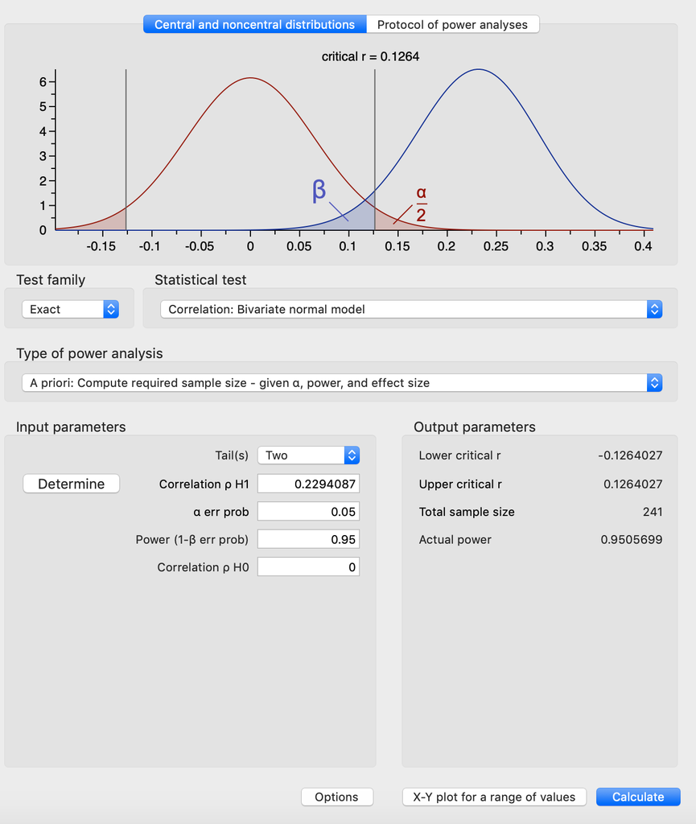

### Planned Sample

Planned sample should have approximately the same demographic characteristics as that in the original study because of AMT recruitment, which was as follows: “…209 adult U.S. residents participated on Amazon Mechanical Turk (52% women; age: M = 38.39 years, SD = 12.83). The target sample size (N = 200) was determined before data collection began, and a total of 209 participants actually completed the study.” No participants were excluded, however, our total sample may ultimately be slightly different based on power analyses. We intend to recruit 146 participants on MTurk based on power analysis, which should give us 80% power.

### Materials

Study materials were made publicly available on the Open Science Framework (OSF), thus, stimuli used in this reproduction are expected to be the same as the original study (see ladder visual below).

**Measure of Comparative Purchase Happiness**: “Comparative purchase happiness was assessed with the question, “Between the two purchases, which made you happier?” Responses were reported on a 7-point scale from −3 (definitely experiential purchase) to 3 (definitely object purchase)."

**Measure of Social Class**: “Participants were shown a ladder with 10 rungs and given the following instructions: Think of this ladder as representing where people stand in the U.S. At the top of the ladder are the people who are the best off—those who have the most money, the most education, and the most respected jobs. At the bottom are the people who are the worst off—who have the least money, least education, and the least respected jobs or no job. The higher up you are on this ladder, the closer you are to the people at the very top; the lower you are, the closer you are to the people at the very bottom.”

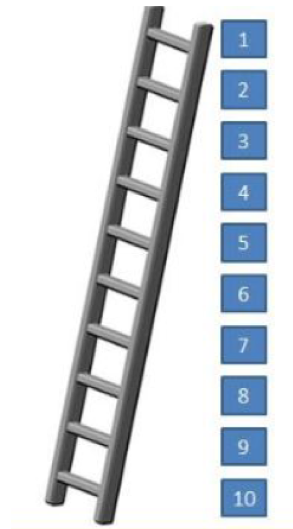

### Procedure

Procedures were followed precisely and are outlined, largely verbatim, below:

“Participants were asked to ‘think about a recent experiential purchase and object purchase that you made to increase your happiness.’ No further information about the definition of these purchases was given.”

“Next, participants reported their social class using the MacArthur Scale of Subjective Social Status…In the past, researchers have measured social class through objective indicators of income, education, or occupation or have used the MacArthur Scale to capture subjective assessment of all three aspects.”

Next, participants were presented with eight demographics questions, including:  
1. About how much is your yearly family income?  
2. About how much is your yearly personal income?  
3. What is the highest level of education you have completed?  
4. What would you describe your family and yourself?  
5. Currently, what is the number of your household? (If a father, a mother, and a child are living together, then the answer would be 3.)  
6. What is your gender?  
7. How old are you? (in years)  
8. What is your race?

**Link to Qualtrics Replication**

https://stanforduniversity.qualtrics.com/jfe/form/SV_cvyQcGW8h07edXn

### Analysis Plan

My analyses will attempt to reproduce the regression from the original paper. I will also calculate the Pearson correlation for the original data and the new data set. I may also plot their data and create a regression table in the final paper.

**Key analysis of interest**

Key confirmatory analysis will be “a regression analysis predicting comparative purchase happiness from social class,” as stated in original publication, which “revealed that social class positively predicted happiness.” My analytic approach should create a similar figure (and correlation) to that in the original article. My current analytic plan does not include standardizing the beta. Both the IV (SES measure) and DV (subjective happiness rating) require reverse coding.

**Strategy**

1. Exclusions: Currently intend to include all participants, as the original study had no exclusions.
2. Cleaning: Tidy data by removing unnecessary columns (e.g., start date, end date, etc.), convert from wide to long, and ensure item values are accurately coded and that question labels from the build-phase translate to being intuitive for data analysis.
3. Analysis: Run a linear regression to see whether SES predicts subjective happiness rating. The original figure indicates that the authors found values where “comparative purchase happiness was significantly different from 0.” After speaking with some stats graduate students, I believe this was determined by using confidence intervals around the fixed values of the regression line and finding the values at which (out to two decimal places) the intervals are no longer inclusive of zero. This is the approach I am going to take in my analysis.

### Differences from Original Study

We can expect some differences will occur (e.g., participant setting or time of study participation, two experimental variables that are not within our control) but, as this study is itself a replication which confirmed the findings of the original, it is not predicted that these differences will have large effects.

## Results

### Data preparation

Data preparation following the analysis plan.

```r
#load library
library("tidyverse")
#import data
 lee <- read_csv("251_Reproduce_October 26, 2019_19.10.csv")
```

### Data Preparation

```r
#Remove first two rows

lee2 <- lee %>%
  filter(!((IPAddress == "IP Address") |
           IPAddress == "{\"ImportId\":\"ipAddress\"}")) %>%

   mutate(subid = row_number()) %>%                     #Insert subject ID row
  select(contains("subid"), CompHap, MacArthurSES)       #Select relevant columns
```

```r
#Makes character class numeric
lee2$CompHap <- as.numeric(lee2$CompHap)
lee2$MacArthurSES <- as.numeric(lee2$MacArthurSES)

#Recoding IV and DV measures and renaming
d <- lee2 %>%
 mutate(ComparativeHappiness=CompHap*-1) %>% # this recodes the two columns
  mutate(MacArthurScale=MacArthurSES*-1)
```

### Confirmatory analysis

*Looking at the p-value*

```r
 summary(lm(ComparativeHappiness~MacArthurScale,data=d))
```

```
##
## Call:
## lm(formula = ComparativeHappiness ~ MacArthurScale, data = d)
##
## Residuals:
##    Min     1Q Median     3Q    Max
## -3.500 -1.725  0.450  1.625  2.400
##
## Coefficients:
##                Estimate Std. Error t value Pr(>|t|)
## (Intercept)      5.1000     4.4878   1.136    0.299
## MacArthurScale   0.9000     0.8406   1.071    0.326
##
## Residual standard error: 2.302 on 6 degrees of freedom
## Multiple R-squared:  0.1604, Adjusted R-squared:  0.02046
## F-statistic: 1.146 on 1 and 6 DF,  p-value: 0.3255
```

*Plotting the model*

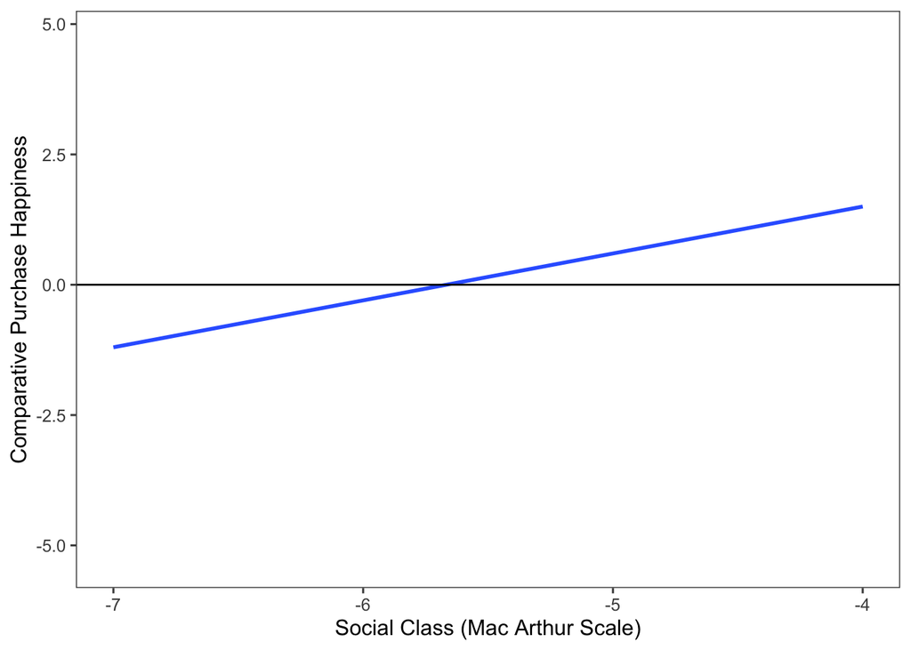

```r
figure <- d %>%
 ggplot(aes(x = MacArthurScale, y = ComparativeHappiness)) +
 geom_smooth(method = "lm", fill = NA)

figure + geom_hline(yintercept=0, color = "black") +
  # geom_vline(xintercept = 0, color = "black") +
    # xlim(c(1, 10)) +
  labs(x = "Social Class (Mac Arthur Scale)") +
  labs(y = "Comparative Purchase Happiness")  +
  ggthemes::theme_few()
```

```r
#Dashed lines (coded below) will be added during pilot b once sample is large enough to evalute
#  geom_vline(xintercept = XX, linetype="dashed", color = "blue") +
 # geom_vline(xintercept = XX, linetype="dashed", color = "blue")
```

*Side-by-side graph with original graph is ideal here*

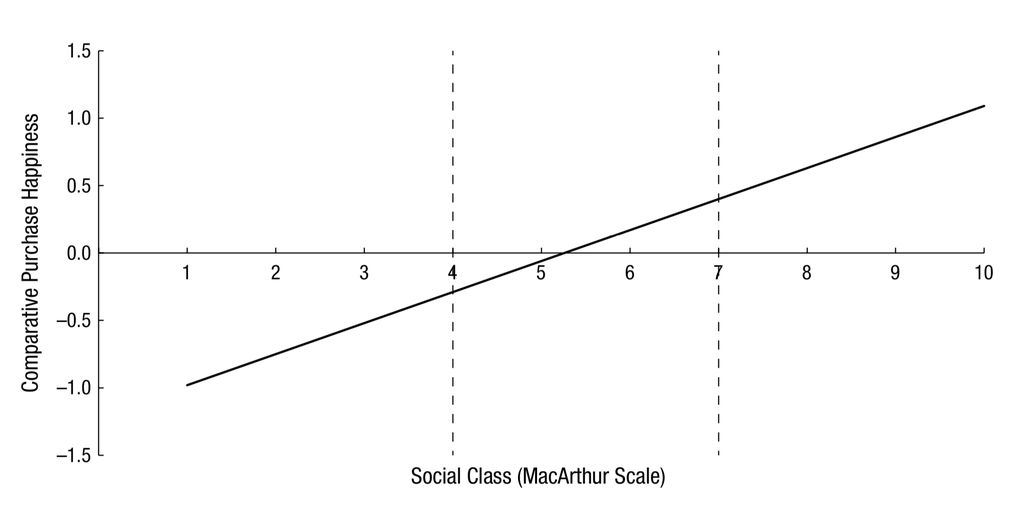

**Original Figure from Lee et al. paper**

### Exploratory analyses

Although not an appropriate analysis to replicate as a key findnig, I intend to also examine where comparative purchase happiness differs significantly from zero (the midpoint of the scale) using confidence intervals for the fitted values of the regression line.

*Getting Pearson correlation*

```r
cor(d$ComparativeHappiness, d$MacArthurScale)
```

```
## [1] 0.4004947
```

*Finding the confidence intervals for fitted values in a linear regression*

```r
l <- lm(ComparativeHappiness~MacArthurScale,data=d)      #run regresssion & assign variable

#Generate a list of CIs for each IV value--locate values that have CIs not intersecting 0

predict(l,newdata = data.frame
        (MacArthurScale=d$MacArthurScale),
        interval="confidence",level = 0.95)
```

```
##    fit       lwr      upr
## 1  0.6 -1.456959 2.656959
## 2 -0.3 -2.819250 2.219250
## 3 -1.2 -5.313918 2.913918
## 4  1.5 -1.752338 4.752338
## 5  1.5 -1.752338 4.752338
## 6  0.6 -1.456959 2.656959
## 7 -0.3 -2.819250 2.219250
## 8  0.6 -1.456959 2.656959
```

```r
#CIs will give interger values that can be manually reviewed to find significant values
  #the 7.02 in the code below is as an example

ci = predict(l,newdata = data.frame
             (MacArthurScale=7.02),
             interval="confidence",level = 0.95)
ci
```

```
##      fit       lwr      upr
## 1 11.418 -13.89935 36.73535
```